# ebnm prior families

Jason Willwerscheid

6/28/2019

## Introduction

Below, I use the following prior families, all of which are constrained to have a unique mode at zero:

- `ebnm_normal`: The family of normal distributions.
- `ebnm_point_normal`: The family of two-component mixtures with one component a point mass at zero and the other a normal distribution (with mean zero). Usually, two parameters need to be estimated: the mixture proportion for the point mass and the variance of the normal component. One can fix the latter using parameter `scale` so that only one parameter needs to be estimated.
- `ebnm_point_laplace`: One component is a point mass at zero and the other is a double-exponential distribution.
- `ebnm_normal_scale_mixture`: The family of scale mixtures of normals.
- `ebnm_ash(mixcompdist = "normal")`: This is also the family of scale mixtures of normals, but whereas `ebnm_normal_scale_mixture` calls into an `ebnm` function that was designed for simplicity and speed, `ebnm_ash` calls directly into the more flexible `ashr::ash`.
- `ebnm_unimodal_symmetric`: The family of symmetric unimodal distributions.
- `ebnm_unimodal`: The general family of unimodal distributions.

## Code

The following functions are used to simulate data and plot results.

```r
mb.times <- 50L # Sets 'times' for microbenchmark

library(ebnm)
library(microbenchmark)
library(ggplot2)

sample <- function(g, ...) {
  UseMethod("sample", g)
}

sample.normalmix <- function(g, nsamp) {
  which.comp <- rmultinom(nsamp, size = 1, prob = g$pi)
  means <- g$mean %*% which.comp
  sds <- g$sd %*% which.comp
  return(rnorm(nsamp, means, sds))
}

sample.unimix <- function(g, nsamp) {
  which.comp <- rmultinom(nsamp, size = 1, prob = g$pi)
  a <- g$a %*% which.comp
  b <- g$b %*% which.comp
  return(runif(nsamp, a, b))
}

cdf <- function(g, ...) {
  UseMethod("cdf", g)
}

cdf.normalmix <- function(g, x) {
  k <- length(g$pi)
  p <- matrix(pnorm(rep(x, each = k), g$mean, g$sd), nrow = k)
  return(as.vector(g$pi %*% p))
}

cdf.unimix <- function(g, x) {
  k <- length(g$pi)
  p <- matrix(punif(rep(x, each = k), g$a, g$b), nrow = k)
  return(as.vector(g$pi %*% p))
}

cdf.laplacemix <- function(g, x) {
  k <- length(g$pi)
  p <- matrix(0.5 * pexp(rep(x, each = k), 1 / g$scale)
              + 0.5 * pexp(rep(-x, each = k), 1 / g$scale,
                           lower.tail = FALSE),
              nrow = k)
  return(as.vector(g$pi %*% p))
}

plot.cdfs <- function(g.list, g.names, xmin, xmax, npts = 100) {
  grid <- seq(xmin, xmax, length.out = npts)
  cdf.list <- lapply(g.list, cdf, x = grid)
  df <- data.frame(x = rep(grid, length(g.list)),
                   cdf = unlist(cdf.list),
                   g = rep(g.names, each = length(grid)))
  ggplot(df, aes(x = x, y = cdf, color = g)) + geom_line()
}
```

## Example 1: mixture of normals

First I simulate observations from the prior

$$g \sim 0.6\ \delta_0 + 0.3\ \text{Normal}(0, 3^2) + 0.1\ \text{Normal}(0, 10^2),$$

which is meant to evoke a point-normal distribution with a slightly heavier tail.

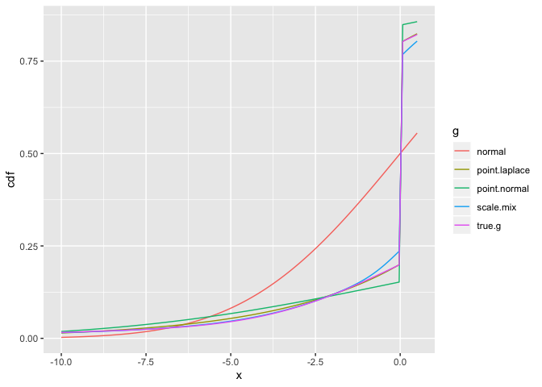

```r
true.g <- ashr::normalmix(pi = c(0.6, 0.3, 0.1),
                          mean = c(0, 0, 0),
                          sd = c(0, 3, 10))

set.seed(666)
n <- 2000
theta <- sample(true.g, n)
s <- 1
x <- theta + rnorm(n)

n.res   <- ebnm_normal(x, s)
pn.res  <- ebnm_point_normal(x, s)
pl.res  <- ebnm_point_laplace(x, s)
smn.res <- ebnm_normal_scale_mixture(x, s)

plot.cdfs(list(true.g, n.res$fitted_g, pn.res$fitted_g, pl.res$fitted_g,
               smn.res$fitted_g),
          g.names = c("true.g", "normal", "point.normal", "point.laplace",
                      "scale.mix"),
          xmin = -10, xmax = 0.5)
```

### Timing: homoskedastic errors

With `s = 1`, a timing comparison yields:

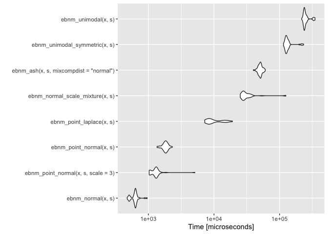

```r
timing.res <- microbenchmark(ebnm_normal(x, s),
                             ebnm_point_normal(x, s, scale = 3),
                             ebnm_point_normal(x, s),
                             ebnm_point_laplace(x, s),
                             ebnm_normal_scale_mixture(x, s),
                             ebnm_ash(x, s, mixcompdist = "normal"),
                             ebnm_unimodal_symmetric(x, s),
                             ebnm_unimodal(x, s),
                             times = mb.times)
autoplot(timing.res)
```

### Timing: heteroskedastic errors

With heteroskedastic errors simulated from a Gamma distribution with shape and rate parameters equal to 1, the timings are:

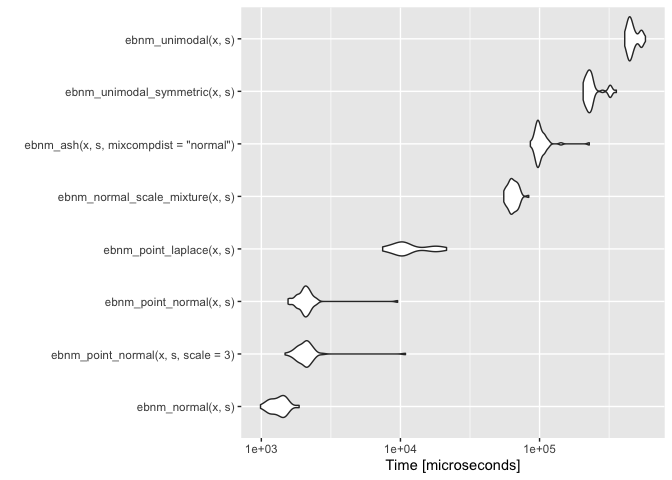

```r
s <- rgamma(n, 1, 1)
timing.res <- microbenchmark(ebnm_normal(x, s),
                             ebnm_point_normal(x, s, scale = 3),
                             ebnm_point_normal(x, s),
                             ebnm_point_laplace(x, s),
                             ebnm_normal_scale_mixture(x, s),
                             ebnm_ash(x, s, mixcompdist = "normal"),
                             ebnm_unimodal_symmetric(x, s),
                             ebnm_unimodal(x, s),
                             times = mb.times)
autoplot(timing.res)
```

## Example 2: mixture of uniforms

I bump `n` up to 20000 to see how it affects the timing comparisons.

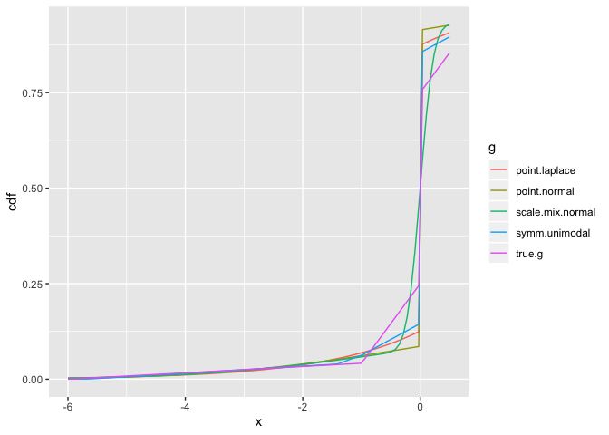

```r
true.g <- ashr::unimix(pi = c(0.5, 0.4, 0.1),
                       a = c(0, -1, -6),
                       b = c(0, 1, 6))

n <- 20000
theta <- sample.unimix(true.g, n)
s <- 1
x <- theta + rnorm(n)

pn.res    <- ebnm_point_normal(x, s)
pl.res    <- ebnm_point_laplace(x, s)
smn.res   <- ebnm_normal_scale_mixture(x, s)
symm.res  <- ebnm_unimodal_symmetric(x, s)

plot.cdfs(list(true.g, pn.res$fitted_g, pl.res$fitted_g, smn.res$fitted_g,
               symm.res$fitted_g),
          c("true.g", "point.normal", "point.laplace", "scale.mix.normal",
            "symm.unimodal"),
          xmin = -6, xmax = 0.5)
```

### Timing: homoskedastic errors

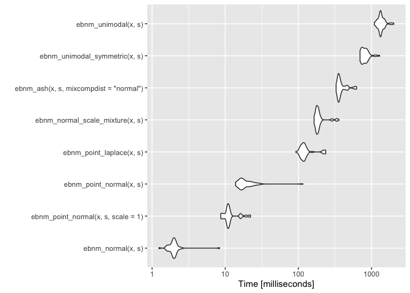

```r
timing.res <- microbenchmark(ebnm_normal(x, s),
                             ebnm_point_normal(x, s, scale = 1),
                             ebnm_point_normal(x, s),
                             ebnm_point_laplace(x, s),
                             ebnm_normal_scale_mixture(x, s),
                             ebnm_ash(x, s, mixcompdist = "normal"),
                             ebnm_unimodal_symmetric(x, s),
                             ebnm_unimodal(x, s),
                             times = mb.times)
autoplot(timing.res)
```

### Timing: heteroskedastic errors

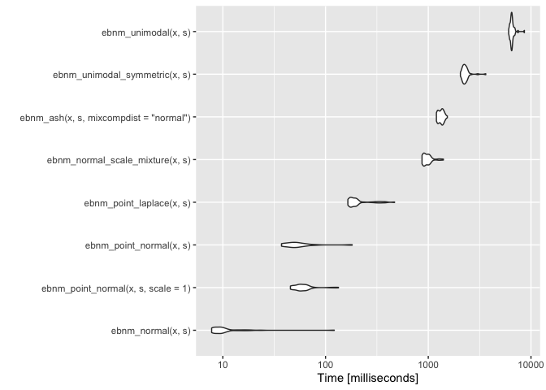

```r
s <- rgamma(n, 1)
timing.res <- microbenchmark(ebnm_normal(x, s),
                             ebnm_point_normal(x, s, scale = 1),
                             ebnm_point_normal(x, s),
                             ebnm_point_laplace(x, s),
                             ebnm_normal_scale_mixture(x, s),
                             ebnm_ash(x, s, mixcompdist = "normal"),
                             ebnm_unimodal_symmetric(x, s),
                             ebnm_unimodal(x, s),
                             times = mb.times)
autoplot(timing.res)
```